# R Guide for Implementing Clustering Step by Step

Customer Segmentation

Author: Alejandra Sarria

Data Analyst | Data Scientist | Analytics translator | Specialist in Data-Driven Decision Making

2025-04-02

**LinkedIn:** www.linkedin.com/in/alejandrasarria

**Blog:** https://datacanvas1.wordpress.com

[figure not shown]

# 1 **Introduction**

This comprehensive guide builds upon the concepts covered in *Introduction to Clustering: Intelligent Data Grouping* by applying clustering techniques to a real-world case: **Customer segmentation**. Customer segmentation is the practice of grouping individuals based on shared characteristics, allowing businesses to better understand and cater to their target audience.

In this case, we will focus on segmenting customers based on their preferences, behaviors, and purchasing habits. By analyzing those, companies can tailor their products, services, and marketing strategies to enhance customer experience and satisfaction.

# 2 **Business Context**

Companies today face the challenge of understanding their customers at a granular level. A one-size-fits-all approach to marketing is no longer effective. Instead, businesses need **data-driven segmentation** to refine their offerings.

**Business Question:**

*“How can we segment our customers effectively based on their personality traits, spending habits, and preferences to enhance business strategies?”*

To address this question, we will use a dataset containing customer attributes such as demographics, income, and spending behavior. Clustering techniques will help us identify distinct customer groups and extract meaningful insights.

# 3 **Dataset Description**

The dataset for this analysis is sourced from Kaggle:  
[Customer Segmentation Dataset](https://www.kaggle.com/datasets/vishakhdapat/customer-segmentation-clustering).

It includes various features that describe customer demographics, economic status, and purchasing behavior, providing a solid foundation for segmentation analysis.

Below is the dictionary of variables available in the dataset:

| Variable | Description |
| --- | --- |
| ID | Unique identifier for each individual in the dataset |
| Year_Birth | The birth year of the individual |
| Education | The highest level of education attained by the individual |
| Marital_Status | The marital status of the individual |
| Income | The annual income of the individual |
| Kidhome | The number of young children in the household |
| Teenhome | The number of teenagers in the household |
| Dt_Customer | The date when the customer was first enrolled or became a part of the company's database |
| Recency | The number of days since the last purchase or interaction |
| MntWines | The amount spent on wines |

[output cut: 19 more lines]

# 4 **Load the data**

This step ensures that we retrieve the dataset programmatically without downloading it manually.

```r
install.packages("httr")
install.packages("jsonlite")

library(httr)
library(jsonlite)
```

Now, we can download the dataset from Kaggle using the following code:

```r
# Read credentials from JSON
kaggle_creds <- fromJSON("C:/Users/YOUR_USER/.kaggle/kaggle.json")

# Define credentials in the environment
Sys.setenv(KAGGLE_USERNAME = kaggle_creds$username)
Sys.setenv(KAGGLE_KEY = kaggle_creds$key)


#Download the .zip file and unzip it
system("kaggle datasets download -d vishakhdapat/customer-segmentation-clustering -p customer_segmentation")
unzip("customer_segmentation/customer-segmentation-clustering.zip", exdir = "customer_segmentation_data")


library(data.table)
```

Using this code, you will download the `.zip` dataset and unzip it inside the folder designated as the working directory. After this, you will be able to load the data easily.

```r
# load the dataset
library(data.table)
library(knitr)
library(kableExtra)

data <- fread("customer_segmentation_data/customer_segmentation.csv")

head(data) %>%
  kable() %>%
  kable_styling(full_width = FALSE) %>%
  scroll_box(width = "100%", height = "300px")    # from package knitr: Creates formatted tables without requiring additional HTML or LaTeX coding
```

| ID | Year_Birth | Education | Marital_Status | Income | Kidhome | Teenhome | Dt_Customer | Recency | MntWines | MntFruits | MntMeatProducts | MntFishProducts | MntSweetProducts | MntGoldProds | NumDealsPurchases | NumWebPurchases | NumCatalogPurchases | NumStorePurchases | NumWebVisitsMonth | AcceptedCmp3 | AcceptedCmp4 | AcceptedCmp5 | AcceptedCmp1 | AcceptedCmp2 | Complain | Z_CostContact | Z_Revenue | Response |
| --- | --- | --- | --- | --- | --- | --- | --- | --- | --- | --- | --- | --- | --- | --- | --- | --- | --- | --- | --- | --- | --- | --- | --- | --- | --- | --- | --- | --- |
| 5524 | 1957 | Graduation | Single | 58138 | 0 | 0 | 04-09-2012 | 58 | 635 | 88 | 546 | 172 | 88 | 88 | 3 | 8 | 10 | 4 | 7 | 0 | 0 | 0 | 0 | 0 | 0 | 3 | 11 | 1 |
| 2174 | 1954 | Graduation | Single | 46344 | 1 | 1 | 08-03-2014 | 38 | 11 | 1 | 6 | 2 | 1 | 6 | 2 | 1 | 1 | 2 | 5 | 0 | 0 | 0 | 0 | 0 | 0 | 3 | 11 | 0 |
| 4141 | 1965 | Graduation | Together | 71613 | 0 | 0 | 21-08-2013 | 26 | 426 | 49 | 127 | 111 | 21 | 42 | 1 | 8 | 2 | 10 | 4 | 0 | 0 | 0 | 0 | 0 | 0 | 3 | 11 | 0 |
| 6182 | 1984 | Graduation | Together | 26646 | 1 | 0 | 10-02-2014 | 26 | 11 | 4 | 20 | 10 | 3 | 5 | 2 | 2 | 0 | 4 | 6 | 0 | 0 | 0 | 0 | 0 | 0 | 3 | 11 | 0 |
| 5324 | 1981 | PhD | Married | 58293 | 1 | 0 | 19-01-2014 | 94 | 173 | 43 | 118 | 46 | 27 | 15 | 5 | 5 | 3 | 6 | 5 | 0 | 0 | 0 | 0 | 0 | 0 | 3 | 11 | 0 |
| 7446 | 1967 | Master | Together | 62513 | 0 | 1 | 09-09-2013 | 16 | 520 | 42 | 98 | 0 | 42 | 14 | 2 | 6 | 4 | 10 | 6 | 0 | 0 | 0 | 0 | 0 | 0 | 3 | 11 | 0 |

# 5 **Data cleaning**

In this section, we will focus on analyzing the quality of the data and conducting some feature engineering.

First, let’s examine the data’s information. Several elements can be reviewed to determine data quality; however, by conducting descriptive statistics, we can gain insight into the data’s structure and content.

```r
library(dplyr)
glimpse(data)
```

```
## Rows: 2,240
## Columns: 29
## $ ID                  <int> 5524, 2174, 4141, 6182, 5324, 7446, 965, 6177, 485…
## $ Year_Birth          <int> 1957, 1954, 1965, 1984, 1981, 1967, 1971, 1985, 19…
## $ Education           <chr> "Graduation", "Graduation", "Graduation", "Graduat…
## $ Marital_Status      <chr> "Single", "Single", "Together", "Together", "Marri…
## $ Income              <int> 58138, 46344, 71613, 26646, 58293, 62513, 55635, 3…
## $ Kidhome             <int> 0, 1, 0, 1, 1, 0, 0, 1, 1, 1, 1, 0, 0, 1, 0, 0, 1,…
## $ Teenhome            <int> 0, 1, 0, 0, 0, 1, 1, 0, 0, 1, 0, 0, 0, 1, 0, 0, 1,…
## $ Dt_Customer         <chr> "04-09-2012", "08-03-2014", "21-08-2013", "10-02-2…
## $ Recency             <int> 58, 38, 26, 26, 94, 16, 34, 32, 19, 68, 11, 59, 82…
## $ MntWines            <int> 635, 11, 426, 11, 173, 520, 235, 76, 14, 28, 5, 6,…
## $ MntFruits           <int> 88, 1, 49, 4, 43, 42, 65, 10, 0, 0, 5, 16, 61, 2, …
## $ MntMeatProducts     <int> 546, 6, 127, 20, 118, 98, 164, 56, 24, 6, 6, 11, 4…
## $ MntFishProducts     <int> 172, 2, 111, 10, 46, 0, 50, 3, 3, 1, 0, 11, 225, 3…
```

[output cut: 16 more lines]

We can check the missing values using the command `data_integrity()`.

```r
library(funModeling)
data_integrity(data)
```

```
## $vars_num_with_NA
##        variable q_na       p_na
## Income   Income   24 0.01071429
##
## $vars_cat_with_NA
## [1] variable q_na     p_na
## <0 rows> (or 0-length row.names)
##
## $vars_cat_high_card
##                variable unique
## Dt_Customer Dt_Customer    663
##
## $MAX_UNIQUE
## [1] 35
##
## $vars_one_value
## [1] "Z_CostContact" "Z_Revenue"
##
## $vars_cat
## [1] "Education"      "Marital_Status" "Dt_Customer"
##
## $vars_num
##  [1] "ID"                  "Year_Birth"          "Income"
##  [4] "Kidhome"             "Teenhome"            "Recency"
##  [7] "MntWines"            "MntFruits"           "MntMeatProducts"
## [10] "MntFishProducts"     "MntSweetProducts"    "MntGoldProds"
## [13] "NumDealsPurchases"   "NumWebPurchases"     "NumCatalogPurchases"
## [16] "NumStorePurchases"   "NumWebVisitsMonth"   "AcceptedCmp3"
## [19] "AcceptedCmp4"        "AcceptedCmp5"        "AcceptedCmp1"
## [22] "AcceptedCmp2"        "Complain"            "Z_CostContact"
## [25] "Z_Revenue"           "Response"
##
## $vars_char
## [1] "Education"      "Marital_Status" "Dt_Customer"
##
## $vars_factor
## character(0)
##
## $vars_other
## character(0)
```

Here are some findings:

- There are 24 missing values in income
- Dt_Customer is not parsed as DateTime
- There are some categorical features in our data frame; as there are some features in dtype: object). So we will need to encode them into numeric forms later.

## 5.1 Handle NA in Clustering

We need to remember that clustering algorithms require complete data to compute distances and group observations. When missing values are present:

- K-Means & K-Medoids
  - K-Means relies on Euclidean distances, which cannot be computed with missing values.
  - In R, the kmeans() function automatically removes rows with NA values.
- Hierarchical Clustering
  - Missing values disrupt the distance matrix, leading to errors or incorrect clustering.

For these reasons, we need to handle NA values before estimating a clustering model.

Missing data is a common challenge in real-world datasets. The way missing values are handled depends on the business question, data distribution, and analytical goals. There is no universal solution; each method has trade-offs. In the following table, you can find a brief description of the different techniques.

| **Handling Method** | **Description** | **When to Use** | **Potential Issues** |
| --- | --- | --- | --- |
| **Remove Missing Values** | Deletes rows with missing values. | When the proportion of missing values is small. | Reduces dataset size, leading to potential information loss. |
| **Leave as Missing** | Retains missing values for careful handling. | When missingness is informative (e.g., survey responses). | Can lead to biased results if not properly addressed. |
| **Mean/Median Imputation** | Replaces missing numerical values with the column mean or median. | When data is missing at random and follows a normal distribution. | Can distort variance and relationships between variables. |
| **Mode Imputation** | Replaces missing categorical values with the most frequent category. | When missing data is minimal and categorical. | Introduces bias if the most common value is not representative. |
| **KNN Imputation** | Predicts missing values using the k-nearest neighbors. | When missing data patterns are similar to observed data. | Computationally expensive; may not work well for sparse datasets. |
| **Gower’s Distance (for Clustering)** | Uses a similarity measure that accommodates missing values. | When clustering mixed-type data with some missing values. | Still requires careful preprocessing to ensure meaningful clusters. |

In this guide, we will use the Remove Missing Values approach to handle missing data. Since the dataset is sourced from Kaggle and we do not have detailed information about how it was collected or processed, we cannot determine whether missing values are random or have a specific pattern. Imputing missing values without understanding their origin could introduce biases or distort the clustering results. Therefore, removing rows with missing values ensures a cleaner dataset and avoids making arbitrary assumptions about the missing data. This approach is particularly useful in exploratory analysis when the proportion of missing data is relatively small.

```r
data2 <- na.omit(data)
```

## 5.2 Dt_Customer as date

In the next step, we will create a new feature based on `Dt_Customer` that indicates how many days each customer has been registered in the firm’s database. To simplify this process, we will calculate this value in relation to the most recent customer registration date. To do this, first, you need to identify the newest and oldest recorded dates in the dataset.

```r
# Load necessary library
library(lubridate)

# Convert 'Dt_Customer' column to date format
data2$Dt_Customer <- dmy(data2$Dt_Customer)  # Use dmy() if the format is "dd-mm-yyyy"

# Find the newest and oldest dates
newest_date <- as.Date(max(data2$Dt_Customer, na.rm = TRUE))  # Convert to Date format
oldest_date <- as.Date(min(data2$Dt_Customer, na.rm = TRUE))  # Convert to Date format

# Print results with proper date formatting
cat("The newest customer's enrolment date in the records:", format(newest_date, "%Y-%m-%d"), "\n")
```

```
## The newest customer's enrolment date in the records: 2014-06-29
```

```r
cat("The oldest customer's enrolment date in the records:", format(oldest_date, "%Y-%m-%d"), "\n")
```

```
## The oldest customer's enrolment date in the records: 2012-07-30
```

Creating a feature (`Customer_For`) of the number of days the customers started to shop in the store relative to the last recorded date

```r
# Create the 'Customer_For' feature (difference in days)
data2$Customer_For <- as.numeric(difftime(newest_date, data2$Dt_Customer, units = "days"))

# Print first few rows to verify
head(data2$Customer_For)
```

```
## [1] 663 113 312 139 161 293
```

## 5.3 Extract the Age

Extract the `Age` from `Year_Birth`, which indicates the birth year of each individual. Since the dataset is outdated, we will use the most recent date available to calculate each person’s age. This involves subtracting “Year_Birth” from the latest recorded date. It’s important to note that this measure is an approximation of age, as we do not have the exact birth date.

```r
# Ensure the 'Year_Birth' column is numeric
data2$Year_Birth <- as.numeric(data2$Year_Birth)

# Calculate Age
data2$Age <- 2014 - data2$Year_Birth

# Check results
head(data2$Age)
```

```
## [1] 57 60 49 30 33 47
```

For a more thorough cleaning process, you might consider recoding certain variables, such as Education and Marital Status, especially if the segmentation processes do not prioritize these characteristics and instead focus on consumption patterns.

## 5.4 Now, let’s explore the data quality.

Once we have the complete data for analysis, we need to check the quality of each variable and look for any inconsistencies that may exist.

We can examine the distribution and outliers using boxplots of selected variables.

Let’s look at some examples using a function that you can utilize for various purposes to create graphs more quickly.

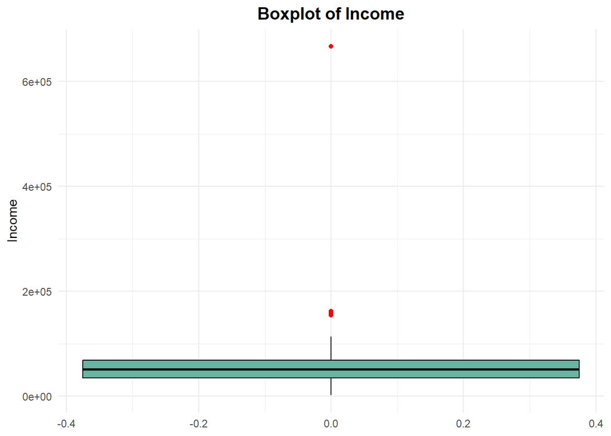

```r
library(ggplot2)


# Define the numerical variables to be graphed

variables <- c("Income", "Age", "Recency", "Customer_For")

# Create a function to generate boxplots
plot_boxplot <- function(var) {
  ggplot(data2, aes(y = .data[[var]])) +
    geom_boxplot(fill = "#69b3a2", color = "black", outlier.color = "red", outlier.shape = 16) +
    theme_minimal() +
    labs(title = paste("Boxplot of", var), y = var) +
    theme(plot.title = element_text(hjust = 0.5, face = "bold", size = 14))
}

# Use lapply for create the graphs
plots <- lapply(variables, plot_boxplot)
print(plots[[1]])
```

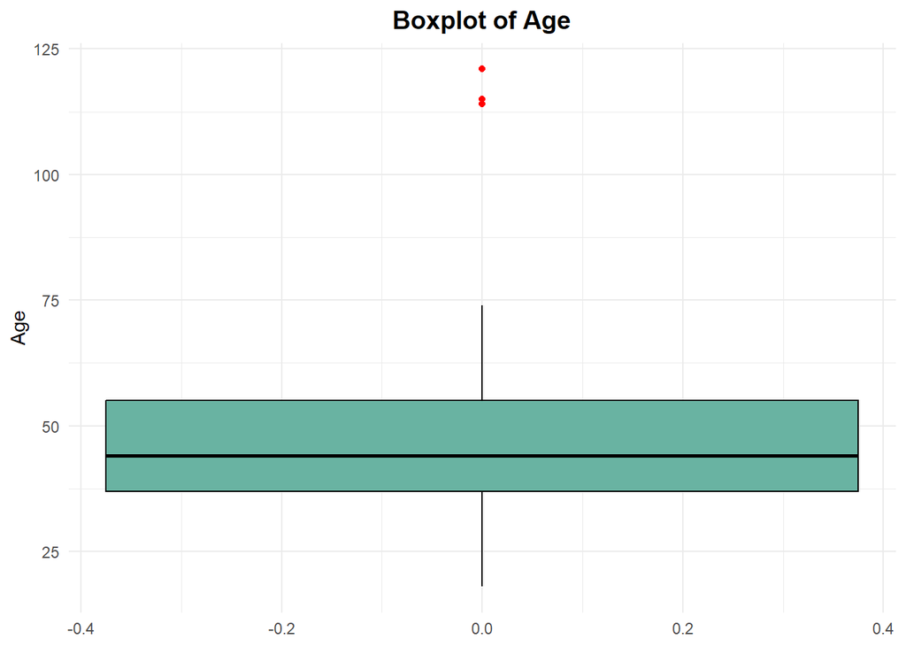

```r
print(plots[[2]])
```

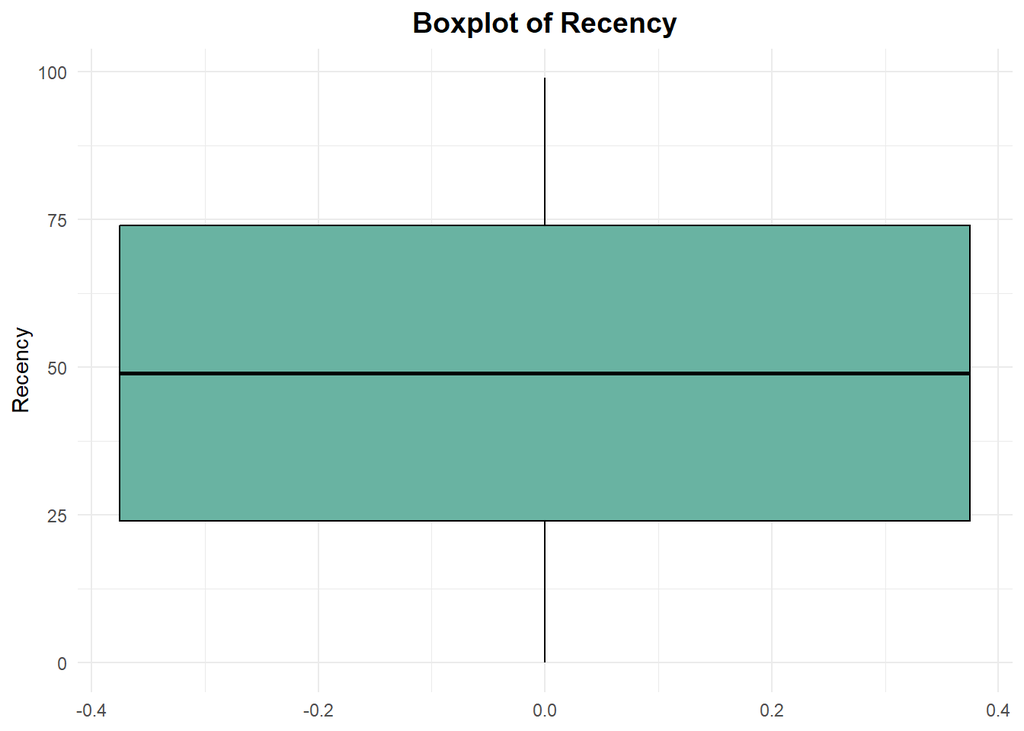

```r
print(plots[[3]])
```

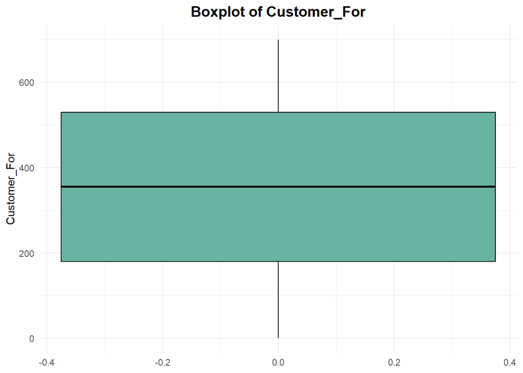

```r
print(plots[[4]])
```

There are a few outliers in the Income and Age features. We will be removing these outliers from the dataset. However, in your real projects, you should first gather more information about these outliers.

`tukey_outlier()`: returns the upper and lower limits used to identify outliers, along with a logical vector indicating which values are outliers. It helps you explore the presence of potential outliers in the `Income` and `Age` variables of the dataframe.

```r
#outliers for Income
threshold_incom<-tukey_outlier(data2$Income)

lower_incom<-as.numeric(threshold_incom[1])

upper_incom<-as.numeric(threshold_incom[2])

 data3<- data2 %>%
    filter(.data[["Income"]] >= lower_incom, .data[["Income"]] <= upper_incom)

#outliers for Age

 threshold_Age<-tukey_outlier(data3$Age)

lower_Age<-as.numeric(threshold_Age[1])

upper_Age<-as.numeric(threshold_Age[2])

 data_fin_all<- data3 %>%
    filter(.data[["Age"]] >= lower_Age, .data[["Age"]] <= upper_Age)
```

## 5.5 Encoding for Multi-Class Categorical Variables

Two common ways to encode multi-class categorical variables are:

### 5.5.1 Label Encoding

This approach assigns a unique integer to each category. For example, categories A, B, and C could be encoded as 0, 1, and 2, respectively. While this method is simple and efficient, it may introduce unintended ordinal relationships between categories, so it’s often better suited for algorithms that can handle such relationships. Here is just an example of how you can encode in R. However, in this guide, we will focus on the One-Hot Encoding approach.

```r
library(dplyr)

data_temp <- data_fin_all %>%
  mutate(Education_encod = as.numeric(factor(Education)))
```

### 5.5.2 One Hot Encoding

This method creates binary (0/1) columns for each category in the variable. For example, if you have a variable with three categories (A, B, C), it will create three new columns: “is_A,” “is_B,” and “is_C.” Each row will have a 1 in the column corresponding to its category and 0s in the others.

The basic strategy is to convert each category value into a new column and assigns a 1 or 0 (True/False) value to the column. This has the benefit of not weighting a value improperly but does have the downside of adding more columns to the data set

```r
library(dplyr)

library(fastDummies)

#Convert categorical variables into dummy variables
data4 <- dummy_cols(data_fin_all, select_columns = c("Education", "Marital_Status"),
                 remove_first_dummy = TRUE,  # Avoids multicollinearity
                 remove_selected_columns = TRUE) # Removes the original categorical columns


head(data4) %>%
  kable() %>%
  kable_styling(full_width = FALSE) %>%
  scroll_box(width = "100%", height = "300px")    # from package knitr: Creates formatted tables without requiring additional HTML or LaTeX coding
```

| ID | Year_Birth | Income | Kidhome | Teenhome | Dt_Customer | Recency | MntWines | MntFruits | MntMeatProducts | MntFishProducts | MntSweetProducts | MntGoldProds | NumDealsPurchases | NumWebPurchases | NumCatalogPurchases | NumStorePurchases | NumWebVisitsMonth | AcceptedCmp3 | AcceptedCmp4 | AcceptedCmp5 | AcceptedCmp1 | AcceptedCmp2 | Complain | Z_CostContact | Z_Revenue | Response | Customer_For | Age | Education_Basic | … |
| --- | --- | --- | --- | --- | --- | --- | --- | --- | --- | --- | --- | --- | --- | --- | --- | --- | --- | --- | --- | --- | --- | --- | --- | --- | --- | --- | --- | --- | --- | --- |
| 5524 | 1957 | 58138 | 0 | 0 | 2012-09-04 | 58 | 635 | 88 | 546 | 172 | 88 | 88 | 3 | 8 | 10 | 4 | 7 | 0 | 0 | 0 | 0 | 0 | 0 | 3 | 11 | 1 | 663 | 57 | 0 | … |
| 2174 | 1954 | 46344 | 1 | 1 | 2014-03-08 | 38 | 11 | 1 | 6 | 2 | 1 | 6 | 2 | 1 | 1 | 2 | 5 | 0 | 0 | 0 | 0 | 0 | 0 | 3 | 11 | 0 | 113 | 60 | 0 | … |
| 4141 | 1965 | 71613 | 0 | 0 | 2013-08-21 | 26 | 426 | 49 | 127 | 111 | 21 | 42 | 1 | 8 | 2 | 10 | 4 | 0 | 0 | 0 | 0 | 0 | 0 | 3 | 11 | 0 | 312 | 49 | 0 | … |
| 6182 | 1984 | 26646 | 1 | 0 | 2014-02-10 | 26 | 11 | 4 | 20 | 10 | 3 | 5 | 2 | 2 | 0 | 4 | 6 | 0 | 0 | 0 | 0 | 0 | 0 | 3 | 11 | 0 | 139 | 30 | 0 | … |
| 5324 | 1981 | 58293 | 1 | 0 | 2014-01-19 | 94 | 173 | 43 | 118 | 46 | 27 | 15 | 5 | 5 | 3 | 6 | 5 | 0 | 0 | 0 | 0 | 0 | 0 | 3 | 11 | 0 | 161 | 33 | 0 | … |
| 7446 | 1967 | 62513 | 0 | 1 | 2013-09-09 | 16 | 520 | 42 | 98 | 0 | 42 | 14 | 2 | 6 | 4 | 10 | 6 | 0 | 0 | 0 | 0 | 0 | 0 | 3 | 11 | 0 | 293 | 47 | 0 | … |

### 5.5.3 Dropping some of the redundant features

Finally, we need to remove the columns that do not contribute any value to the analysis.

```r
#library(dplyr)

# Dropping redundant columns
to_drop <- c( "Dt_Customer", "Z_CostContact",
             "Z_Revenue", "Year_Birth", "ID", "Response", "Complain", "AcceptedCmp1",
             "AcceptedCmp2", "AcceptedCmp3", "AcceptedCmp4", "AcceptedCmp5")

data5 <- data4 %>% select(-all_of(to_drop))

# Check the structure after dropping columns

head(data5) %>%
  kable() %>%
  kable_styling(full_width = FALSE) %>%
  scroll_box(width = "100%", height = "300px")    # from package knitr: Creates formatted tables without requiring additional HTML or LaTeX coding
```

| Income | Kidhome | Teenhome | Recency | MntWines | MntFruits | MntMeatProducts | MntFishProducts | MntSweetProducts | MntGoldProds | NumDealsPurchases | NumWebPurchases | NumCatalogPurchases | NumStorePurchases | NumWebVisitsMonth | Customer_For | Age | Education_Basic | Education_Graduation | Education_Master | Education_PhD | Marital_Status_Alone | Marital_Status_Divorced | Marital_Status_Married | Marital_Status_Single | Marital_Status_Together | Marital_Status_Widow | Marital_Status_YOLO |
| --- | --- | --- | --- | --- | --- | --- | --- | --- | --- | --- | --- | --- | --- | --- | --- | --- | --- | --- | --- | --- | --- | --- | --- | --- | --- | --- | --- |
| 58138 | 0 | 0 | 58 | 635 | 88 | 546 | 172 | 88 | 88 | 3 | 8 | 10 | 4 | 7 | 663 | 57 | 0 | 1 | 0 | 0 | 0 | 0 | 0 | 1 | 0 | 0 | 0 |
| 46344 | 1 | 1 | 38 | 11 | 1 | 6 | 2 | 1 | 6 | 2 | 1 | 1 | 2 | 5 | 113 | 60 | 0 | 1 | 0 | 0 | 0 | 0 | 0 | 1 | 0 | 0 | 0 |
| 71613 | 0 | 0 | 26 | 426 | 49 | 127 | 111 | 21 | 42 | 1 | 8 | 2 | 10 | 4 | 312 | 49 | 0 | 1 | 0 | 0 | 0 | 0 | 0 | 0 | 1 | 0 | 0 |
| 26646 | 1 | 0 | 26 | 11 | 4 | 20 | 10 | 3 | 5 | 2 | 2 | 0 | 4 | 6 | 139 | 30 | 0 | 1 | 0 | 0 | 0 | 0 | 0 | 0 | 1 | 0 | 0 |
| 58293 | 1 | 0 | 94 | 173 | 43 | 118 | 46 | 27 | 15 | 5 | 5 | 3 | 6 | 5 | 161 | 33 | 0 | 0 | 0 | 1 | 0 | 0 | 1 | 0 | 0 | 0 | 0 |
| 62513 | 0 | 1 | 16 | 520 | 42 | 98 | 0 | 42 | 14 | 2 | 6 | 4 | 10 | 6 | 293 | 47 | 0 | 0 | 1 | 0 | 0 | 0 | 0 | 0 | 1 | 0 | 0 |

Now that the data is quite clean and the new features have been included, we will proceed to the next step: preprocessing the data through standardization.

## 5.6 Standardization

When performing clustering, it is essential to scale the data to ensure that variables with larger ranges do not dominate the distance calculations. The `scale()` function standardizes numerical variables by converting them to z-scores, which have:

- Mean = 0
- Standard deviation = 1

```r
data_scaled  <- as.data.frame(scale(data5))


head(data_scaled) %>%
  kable() %>%
  kable_styling(full_width = FALSE) %>%
  scroll_box(width = "100%", height = "300px")    # from package knitr: Creates formatted tables without requiring additional HTML or LaTeX coding
```

| Income | Kidhome | Teenhome | Recency | MntWines | MntFruits | MntMeatProducts | MntFishProducts | MntSweetProducts | MntGoldProds | NumDealsPurchases | NumWebPurchases | NumCatalogPurchases | NumStorePurchases | NumWebVisitsMonth | Customer_For | Age | Education_Basic | Education_Graduation | Education_Master | Education_PhD | Marital_Status_Alone | Marital_Status_Divorced | Marital_Status_Married | Marital_Status_Single | Marital_Status_Together | Marital_Status_Widow | Marital_Status_YOLO |
| --- | --- | --- | --- | --- | --- | --- | --- | --- | --- | --- | --- | --- | --- | --- | --- | --- | --- | --- | --- | --- | --- | --- | --- | --- | --- | --- | --- |
| 0.2870400 | -0.8225675 | -0.9294885 | 0.3102831 | 0.9774386 | 1.5516896 | 1.6899111 | 2.4529173 | 1.4833771 | 0.8523828 | 0.3509506 | 1.4265420 | 2.5030413 | -0.5556886 | 0.6920240 | 1.5273754 | 1.0181218 | -0.1581514 | 0.9916712 | -0.4444417 | -0.5263183 | -0.0368438 | -0.3414016 | -0.7951015 | 1.924762 | -0.5897468 | -0.1885854 | -0.030076 |
| -0.2608231 | 1.0397860 | 0.9078918 | -0.3807274 | -0.8724207 | -0.6373172 | -0.7180674 | -0.6508565 | -0.6338753 | -0.7334766 | -0.1686630 | -1.1261653 | -0.5712104 | -1.1708955 | -0.1325152 | -1.1887425 | 1.2744970 | -0.1581514 | 0.9916712 | -0.4444417 | -0.5263183 | -0.0368438 | -0.3414016 | -0.7951015 | 1.924762 | -0.5897468 | -0.1885854 | -0.030076 |
| 0.9129900 | -0.8225675 | -0.9294885 | -0.7953337 | 0.3578543 | 0.5704107 | -0.1785018 | 1.3392102 | -0.1471506 | -0.0372456 | -0.6882765 | 1.4265420 | -0.2296269 | 1.2899319 | -0.5447849 | -0.2060017 | 0.3344545 | -0.1581514 | 0.9916712 | -0.4444417 | -0.5263183 | -0.0368438 | -0.3414016 | -0.7951015 | -0.519310 | 1.6948765 | -0.1885854 | -0.030076 |
| -1.1758481 | 1.0397860 | -0.9294885 | -0.7953337 | -0.8724207 | -0.5618342 | -0.6556383 | -0.5047966 | -0.5852028 | -0.7528163 | -0.1686630 | -0.7614928 | -0.9127940 | -0.5556886 | 0.2797544 | -1.0603442 | -1.2892552 | -0.1581514 | 0.9916712 | -0.4444417 | -0.5263183 | -0.0368438 | -0.3414016 | -0.7951015 | -0.519310 | 1.6948765 | -0.1885854 | -0.030076 |
| 0.2942401 | 1.0397860 | -0.9294885 | 1.5541019 | -0.3921688 | 0.4194448 | -0.2186348 | 0.1524732 | -0.0011332 | -0.5594188 | 1.3901777 | 0.3325246 | 0.1119566 | 0.0595182 | -0.1325152 | -0.9516995 | -1.0328800 | -0.1581514 | -1.0079429 | -0.4444417 | 1.8991319 | -0.0368438 | -0.3414016 | 1.2571325 | -0.519310 | -0.5897468 | -0.1885854 | -0.030076 |
| 0.4902705 | -0.8225675 | 0.9078918 | -1.1408389 | 0.6365191 | 0.3942838 | -0.3078192 | -0.6873715 | 0.3639103 | -0.5787586 | -0.1686630 | 0.6971970 | 0.4535402 | 1.2899319 | 0.2797544 | -0.2998312 | 0.1635377 | -0.1581514 | -1.0079429 | 2.2489967 | -0.5263183 | -0.0368438 | -0.3414016 | -0.7951015 | -0.519310 | 1.6948765 | -0.1885854 | -0.030076 |

# 6 **Dimensionality reduction with PCA**

In many clustering problems, various factors contribute to the final classification, and these factors are typically referred to as attributes or features. As the number of features increases, the complexity of data analysis also grows, with many features potentially being correlated and redundant. Therefore, performing dimensionality reduction on the selected features before running a clustering model can simplify the dataset and enhance the effectiveness of the clustering process.

In this guide, we will focus on analyzing a reduced dataset. However, in real-life scenarios, the decision depends on the number of variables and the specific objectives of the analysis. You may choose to run the clustering model using the resulting dataset obtained in the previous section (with all variables). Additionally, it can be insightful to compare the results from both the reduced dataset and the original data.

**Principal Component Analysis (PCA)** is a widely used technique for reducing the dimensionality of a dataset while preserving as much variance as possible. By transforming correlated variables into a smaller set of uncorrelated components, PCA enhances model performance and interpretability.

The **scree plot** helps decide the number of principal components based on the explained variance.

```r
library(tidyverse)   # For data manipulation and plotting
library(factoextra)  # For PCA visualization

# Perform PCA
pca_result <- prcomp(data_scaled, center = TRUE, scale. = TRUE)

# Summary of PCA to check variance explained
summary(pca_result)
```

```
## Importance of components:
##                           PC1     PC2    PC3     PC4     PC5     PC6     PC7
## Standard deviation     2.5130 1.47735 1.3281 1.22954 1.19709 1.13659 1.10585
## Proportion of Variance 0.2255 0.07795 0.0630 0.05399 0.05118 0.04614 0.04367
## Cumulative Proportion  0.2255 0.30349 0.3665 0.42048 0.47166 0.51780 0.56147
##                            PC8     PC9    PC10    PC11    PC12    PC13    PC14
## Standard deviation     1.05573 1.04885 1.02545 1.00232 0.96986 0.96176 0.89061
## Proportion of Variance 0.03981 0.03929 0.03756 0.03588 0.03359 0.03303 0.02833
## Cumulative Proportion  0.60128 0.64057 0.67812 0.71401 0.74760 0.78063 0.80896
##                           PC15    PC16    PC17    PC18    PC19    PC20    PC21
## Standard deviation     0.84976 0.83383 0.79268 0.74304 0.66778 0.64984 0.64565
## Proportion of Variance 0.02579 0.02483 0.02244 0.01972 0.01593 0.01508 0.01489
## Cumulative Proportion  0.83475 0.85958 0.88202 0.90174 0.91767 0.93275 0.94764
##                           PC22   PC23    PC24    PC25    PC26    PC27    PC28
## Standard deviation     0.62186 0.5676 0.48857 0.47575 0.40142 0.36047 0.03485
## Proportion of Variance 0.01381 0.0115 0.00852 0.00808 0.00575 0.00464 0.00004
## Cumulative Proportion  0.96145 0.9729 0.98148 0.98956 0.99532 0.99996 1.00000
```

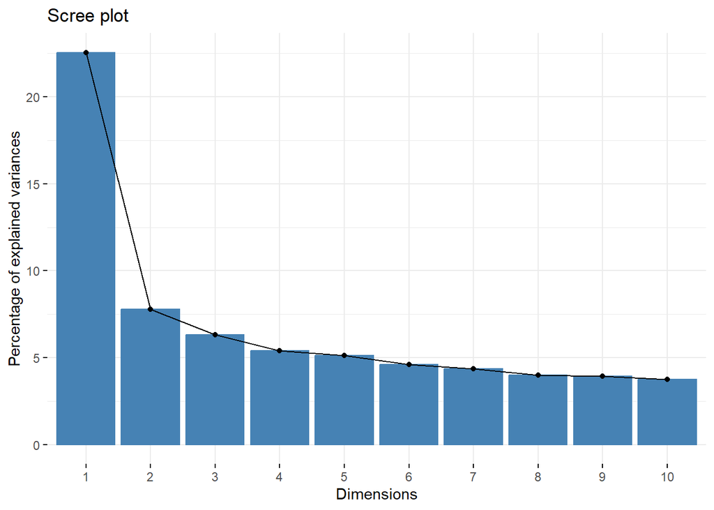

```r
# Scree plot to visualize the importance of each component
fviz_eig(pca_result)
```

In this case, we will be reducing the dimensions to 3.

```r
# Extract first 3 principal components
pca_data <- as.data.frame(pca_result$x[, 1:3])

colnames(pca_data) <- c("PC1", "PC2", "PC3")
```

**Visualize PCA Results**

```r
library(plotly)  # For interactive 3D plots

plot_ly(pca_data, x = ~PC1, y = ~PC2, z = ~PC3,
        type = "scatter3d", mode = "markers")
```

[interactive chart not shown]

# 7 **Clustering**

Now that we have reduced the number of attributes to three dimensions, we will proceed with applying clustering methods. In this guide, we will explore two types of clustering techniques: Agglomerative Clustering and K-Means.

## 7.1 Agglomerative Clustering

**Agglomerative Clustering** is a hierarchical clustering method that starts with each data point as its own cluster and merges them step by step based on similarity. The process continues until all data points belong to a single cluster.

Steps:

1️⃣ Compute the distance matrix between points.

2️⃣ Apply Hierarchical Agglomerative Clustering using Ward’s method.

3️⃣ Visualize the dendrogram to analyze the cluster hierarchy.

4️⃣ Cut the tree to obtain k clusters.

5️⃣ Visualize the clustered data.

### 7.1.1 Compute the distance matrix between points

```r
data_dist <- dist(pca_data)
class(data_dist)
```

```
## [1] "dist"
```

### 7.1.2 Apply Hierarchical Agglomerative Clustering

```r
agg_clust <- hclust(data_dist, method = "ward.D2")  # Ward’s method
agg_clust
```

```
##
## Call:
## hclust(d = data_dist, method = "ward.D2")
##
## Cluster method   : ward.D2
## Distance         : euclidean
## Number of objects: 2212
```

### 7.1.3 Visualize the dendrogram to analyze the cluster hierarchy

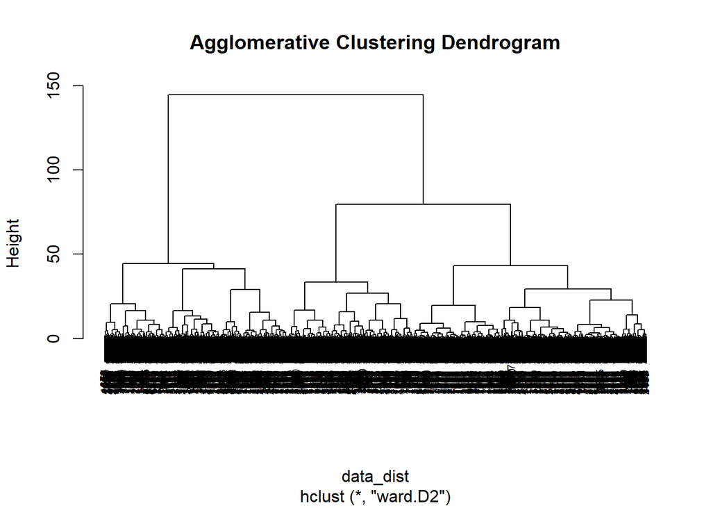

```r
# ---- Visualize the Dendrogram ----
plot(agg_clust, main = "Agglomerative Clustering Dendrogram", cex = 0.6)
```

### 7.1.4 Cut the tree to obtain k clusters and visualize them

An important question is: **Where should we cut the dendrogram?** To address this, we can utilize several techniques. There are three common clustering evaluation methods for identifying the optimal number of clusters. However, for Agglomerative Clustering, it is advisable to use two of these methods (metrics and silhouette analysis) together with the dendrogram for a more comprehensive understanding. These approaches will help us determine the optimal number of clusters. Please refer to the following table for more information about these methods.

**Comparison Table: Clustering Evaluation Methods**

| **Method** | **K-Means** | **Hierarchical** | **How It Works** | **Pros** | **Cons** |
| --- | --- | --- | --- | --- | --- |
| **Elbow Method** | ✅ Yes | ⚠️ Less effective | Evaluates the sum of squared distances within clusters (WCSS) and finds the “elbow” where adding more clusters doesn’t significantly reduce variance. | Simple to interpret; works well for spherical clusters. | Less effective for hierarchical clustering; subjective elbow point. |
| **NbClust (30 indices)** | ✅ Yes | ✅ Yes | Uses multiple indices (e.g., Dunn, Silhouette, Gap Statistic) to determine the optimal number of clusters. | Provides multiple validation criteria; works for both clustering methods. | Different indices may suggest different cluster numbers, requiring careful interpretation. |
| **Silhouette Method** | ✅ Yes | ✅ Yes | Measures how similar each point is to its own cluster compared to others. A higher silhouette score means better clustering. | Works for both K-Means and hierarchical clustering; provides clear quality metrics. | Doesn’t always work well for non-spherical clusters. |

#### 7.1.4.1 Employing metrics

One way to determine the optimal number of clusters is to use the 30 most commonly employed indicators. These are available in the NbClust package (Charrad et al., 2014) using the NbClust() function. This function typically includes the following arguments:

```
NbClust(data = NULL, diss = NULL, distance = “euclidean”, min.nc = 2, max.nc = 15, method =
NULL, index = “all”)
```

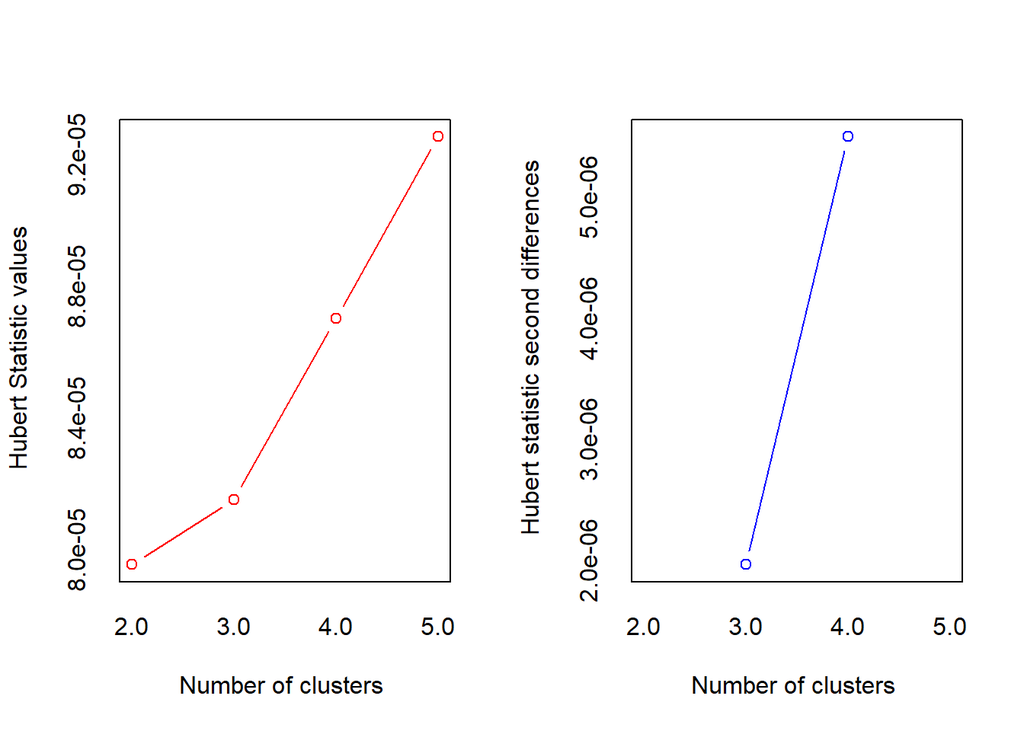

```
## *** : The Hubert index is a graphical method of determining the number of clusters.
##                 In the plot of Hubert index, we seek a significant knee that corresponds to a
##                 significant increase of the value of the measure i.e the significant peak in Hubert
##                 index second differences plot.
##
```

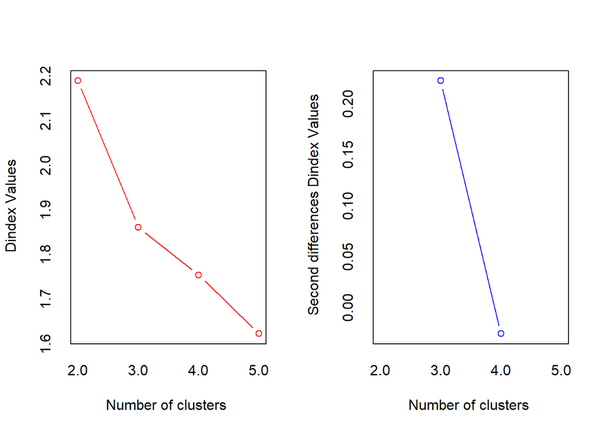

```
## *** : The D index is a graphical method of determining the number of clusters.
##                 In the plot of D index, we seek a significant knee (the significant peak in Dindex
##                 second differences plot) that corresponds to a significant increase of the value of
##                 the measure.
##
## * Among all indices:
## * 10 proposed 2 as the best number of clusters
## * 11 proposed 3 as the best number of clusters
## * 1 proposed 4 as the best number of clusters
## * 2 proposed 5 as the best number of clusters
##
##                    ***** Conclusion *****
##
## * According to the majority rule, the best number of clusters is  3
##
##
```

```r
library(NbClust)
# calculate the 30 most commonly employed indicators
set.seed(12345)
res_ward <- NbClust(pca_data, distance = "euclidean", min.nc = 2,
max.nc = 5, method = "ward.D2", index = "all")
```

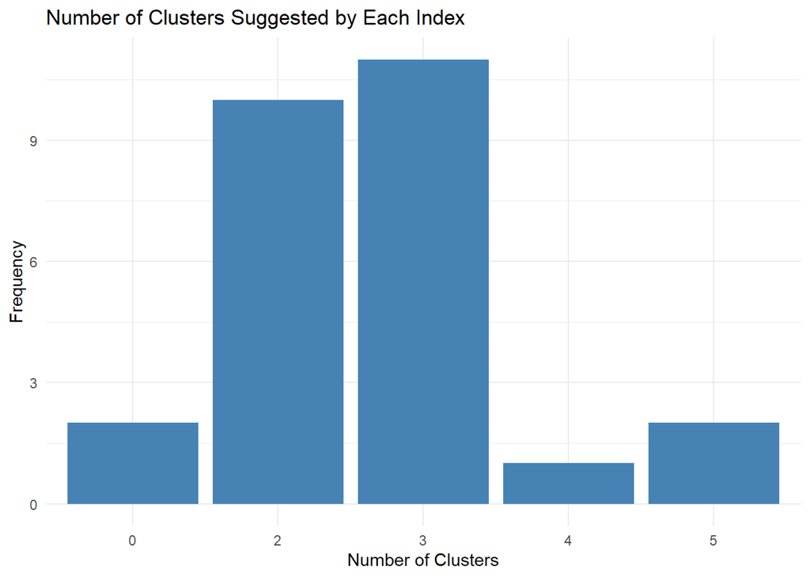

```r
# Print the number of clusters suggested by each index
cluster_freq <- as.data.frame(table(res_ward$Best.nc[1, ]))

# Rename the columns for easier understanding
colnames(cluster_freq) <- c("Number_of_Clusters", "Frequency")

# Create a bar graph using ggplot2
ggplot(cluster_freq, aes(x = Number_of_Clusters, y = Frequency)) +
  geom_bar(stat = "identity", fill = "steelblue") +
  theme_minimal() +
  labs(title = "Number of Clusters Suggested by Each Index",
       x = "Number of Clusters",
       y = "Frequency")
```

From this analysis, we observe that a potential optimal number of clusters is three.

#### 7.1.4.2 Silhouette analysis

Another complementary approach for determining the number of clusters is to use silhouette plots. These graphs illustrate how well each observation fits within its assigned cluster by comparing its proximity to other observations within the same group, given a specific number of clusters. Values close to one indicate that the observation is well-clustered, while values near zero or less suggest that the individual may have been misclassified within its cluster.

```
silhouette(x, dist, dmatrix)
```

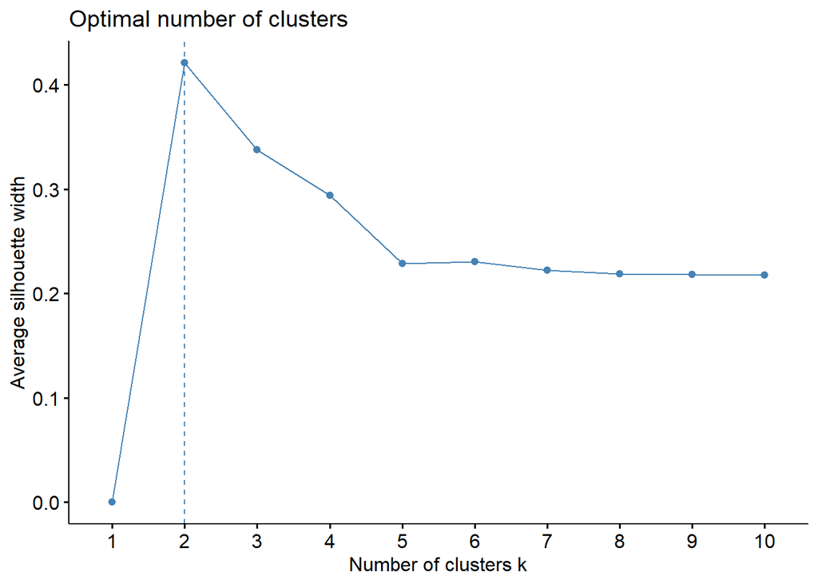

```r
fviz_nbclust(pca_data, hcut, method = "silhouette")
```

From this analysis, we observe that a potential optimal number of clusters is two. Next, let’s examine each result more closely.

```r
library(cluster)
library(factoextra)
library(ggplot2)
library(patchwork)

# Calculate the distance matrix

dist_matrix <- dist(pca_data)

#  2 clusters
hc2 <- hclust(dist_matrix, method = "ward.D2")
clusters2 <- cutree(hc2, 2)
sil2 <- silhouette(clusters2, dist_matrix)

#  3 clusters
hc3 <- hclust(dist_matrix, method = "ward.D2")
clusters3 <- cutree(hc3, 3)
sil3 <- silhouette(clusters3, dist_matrix)

# Calculate the silhouette averages

avg_sil2 <- round(mean(sil2[, 3]), 3)
avg_sil3 <- round(mean(sil3[, 3]), 3)

# graph with fviz_silhouette()
p1 <- fviz_silhouette(sil2) + ggtitle(paste("Silhouette Plot - 2 Clusters (Avg:", avg_sil2, ")"))
```

```
##   cluster size ave.sil.width
## 1       1  749          0.43
## 2       2 1463          0.42
```

```r
p2 <- fviz_silhouette(sil3) + ggtitle(paste("Silhouette Plot - 3 Clusters (Avg:", avg_sil3, ")"))
```

```
##   cluster size ave.sil.width
## 1       1  749          0.32
## 2       2  952          0.40
## 3       3  511          0.25
```

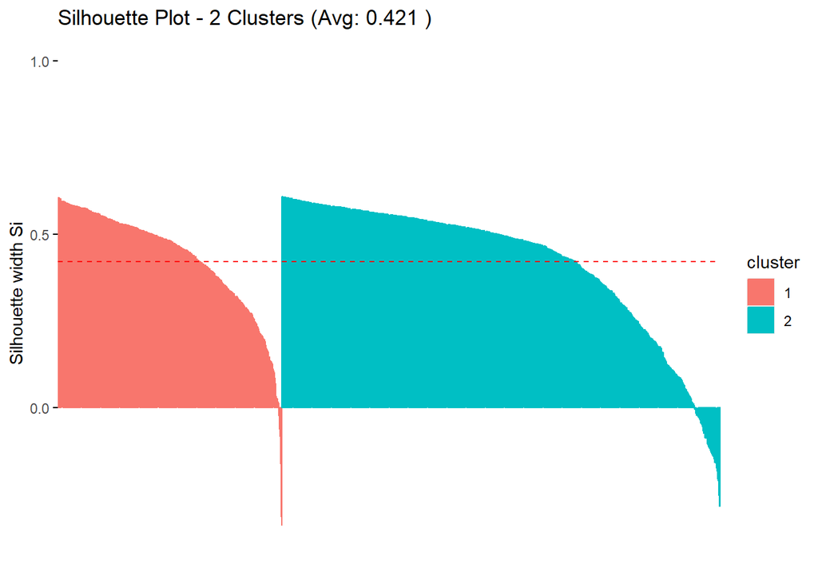

```r
p1
```

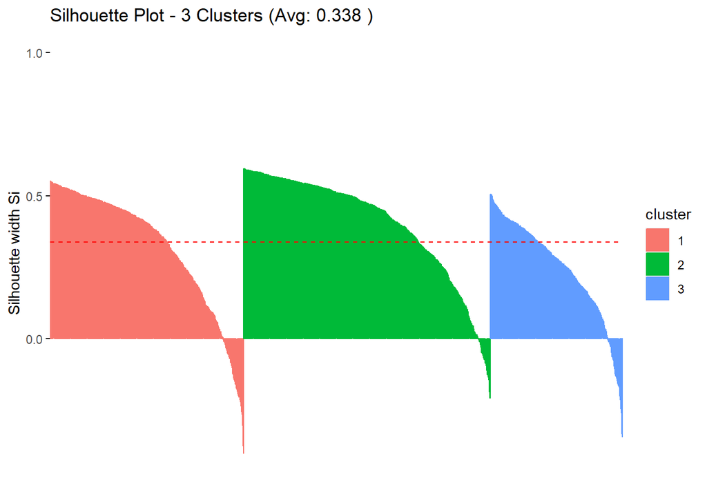

```r
p2
```

The results indicate that each cluster exhibits higher silhouette values when we identify **two clusters** as the optimal number. Later, we will compare this outcome with the k-means findings.

#### 7.1.4.3 Visualize the clustered data

This scatter plot represents the results of Agglomerative Clustering applied to PCA-reduced data, with the first two principal components (PC1 & PC2) as axes. The data points are color-coded according to their assigned cluster.

- The data points are divided into two main groups, but the cluster boundary is irregular.
- There is mixing of colors at the boundary, suggesting that Agglomerative Clustering does not separate the data as clearly
- The method groups similar points together based on proximity, progressively merging them into clusters.

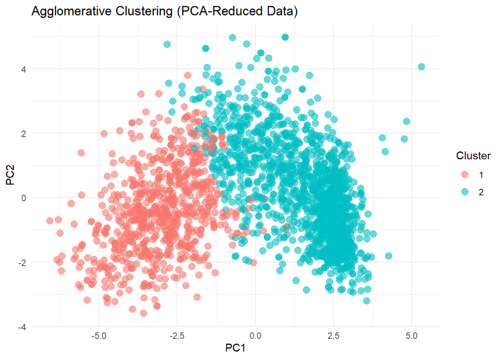

```r
pca_data_ag<- pca_data

#### Visualize the clustered data

k_opt_ag<-2
# ---- Cut the Dendrogram to Obtain Clusters ----
pca_data_ag$Cluster_Agglomerative <- as.factor(cutree(agg_clust, k = k_opt_ag))

# ---- Visualize the Clusters ----
ggplot(pca_data_ag, aes(x = PC1, y = PC2, color = Cluster_Agglomerative)) +
  geom_point(alpha = 0.6, size = 3) +
  theme_minimal() +
  labs(title = "Agglomerative Clustering (PCA-Reduced Data)", color = "Cluster")
```

## 7.2 K-Means Clustering

K-Means is a partitioning algorithm that divides the dataset into k clusters. It minimizes the sum of squared distances within each cluster. The algorithm iteratively assigns data points to the closest centroid and recalculates centroids until convergence.

Steps:

1️⃣ Determine the optimal number of clusters.

2️⃣ Apply K-Means to the PCA-reduced dataset.

3️⃣ Visualize the clustered data.

### 7.2.1 Determine the optimal number of clusters

We can determine the optimal number of clusters by applying the three clustering evaluation methods.

#### 7.2.1.1 Elbow Method

The Elbow Method helps determine the optimal number of clusters by plotting the within-cluster sum of squares (WSS) for different numbers of clusters. The idea is to find the “elbow point,” where adding more clusters does not significantly reduce the WSS, meaning additional clusters do not improve the segmentation.

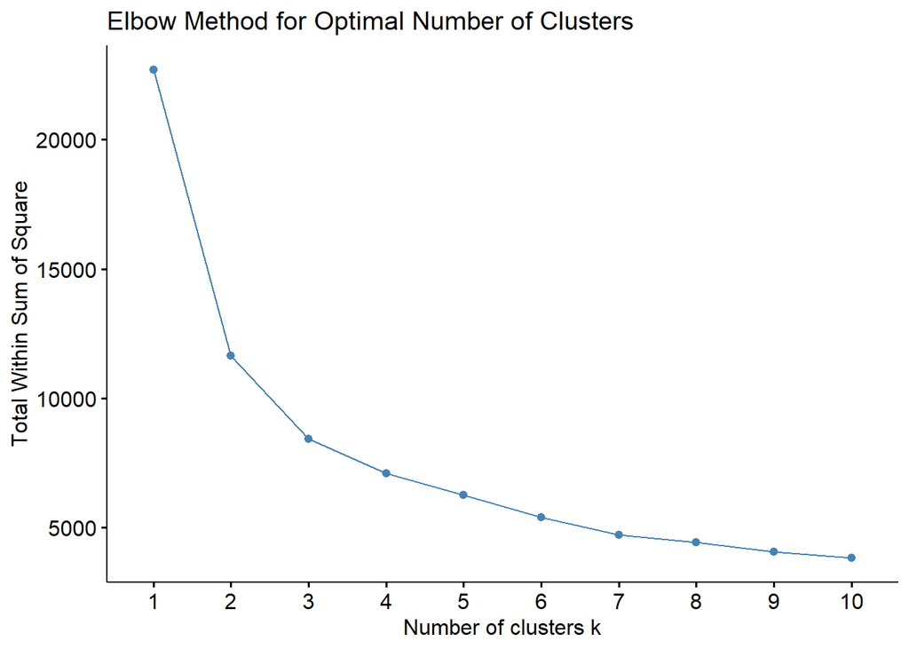

```r
set.seed(12345)
fviz_nbclust(pca_data, kmeans, method = "wss") +
  ggtitle("Elbow Method for Optimal Number of Clusters")
```

**Interpretation:**

- The optimal number of clusters is where the WSS curve bends sharply (elbow point).
- If the plot does not have a clear elbow, we should complement this method with the Silhouette Method or NbClust.

In this case, the number of clusters appears to be three; however, we need to complement this finding with the other methods.

#### 7.2.1.2 Employing metrics

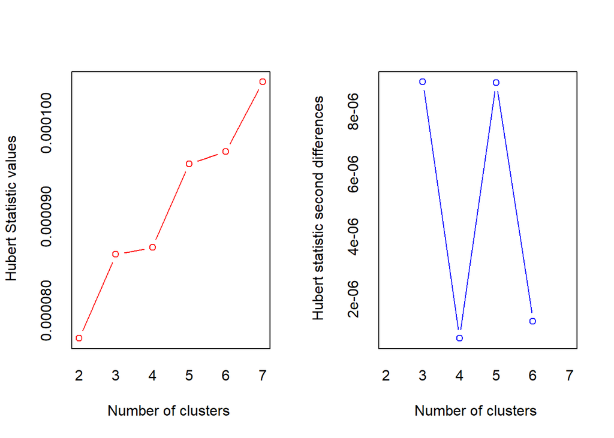

```
## *** : The Hubert index is a graphical method of determining the number of clusters.
##                 In the plot of Hubert index, we seek a significant knee that corresponds to a
##                 significant increase of the value of the measure i.e the significant peak in Hubert
##                 index second differences plot.
##
```

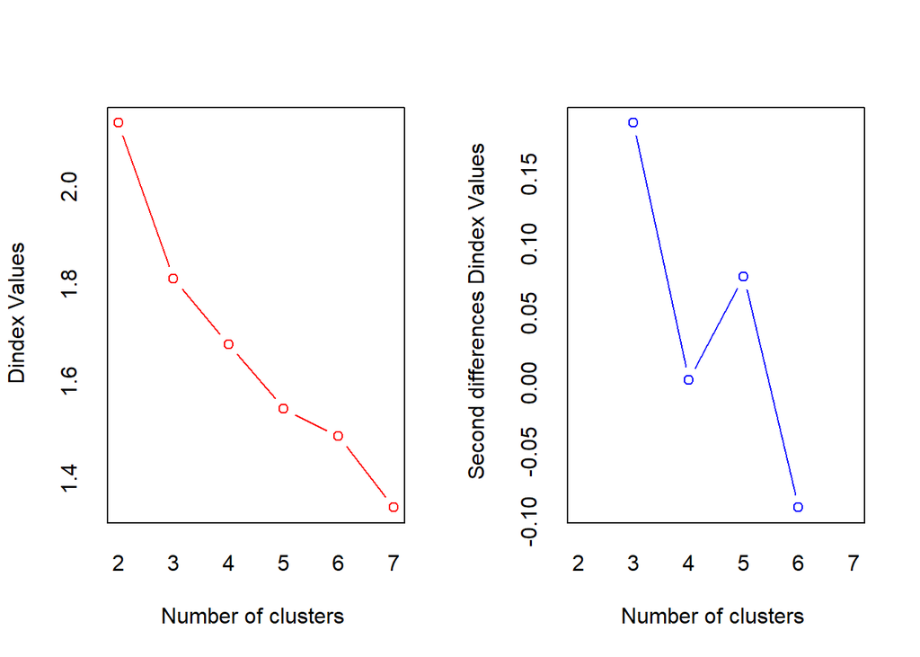

```
## *** : The D index is a graphical method of determining the number of clusters.
##                 In the plot of D index, we seek a significant knee (the significant peak in Dindex
##                 second differences plot) that corresponds to a significant increase of the value of
##                 the measure.
##
## * Among all indices:
## * 11 proposed 2 as the best number of clusters
## * 10 proposed 3 as the best number of clusters
## * 1 proposed 4 as the best number of clusters
## * 1 proposed 7 as the best number of clusters
##
##                    ***** Conclusion *****
##
## * According to the majority rule, the best number of clusters is  2
##
##
```

```r
library(NbClust)

set.seed(12345)
res_kmeans <- NbClust(pca_data, distance = "euclidean", min.nc = 2,
max.nc = 7, method = "kmeans", index = "all")
```

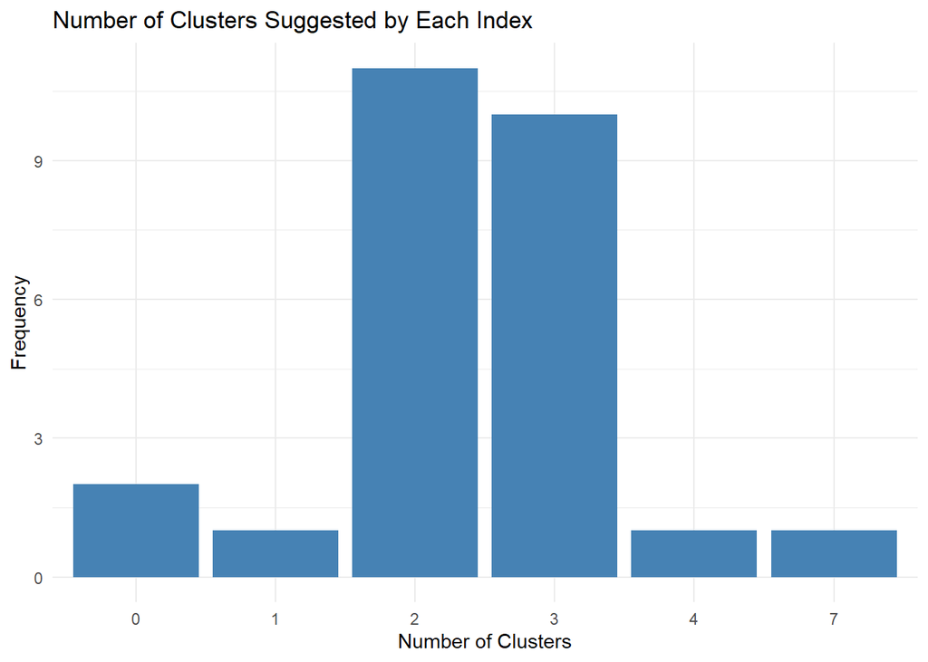

```r
# Print the number of clusters suggested by each index
cluster_freq <- as.data.frame(table(res_kmeans$Best.nc[1, ]))

# Rename the columns for easier understanding
colnames(cluster_freq) <- c("Number_of_Clusters", "Frequency")

# Create a bar graph using ggplot2
ggplot(cluster_freq, aes(x = Number_of_Clusters, y = Frequency)) +
  geom_bar(stat = "identity", fill = "steelblue") +
  theme_minimal() +
  labs(title = "Number of Clusters Suggested by Each Index",
       x = "Number of Clusters",
       y = "Frequency")
```

These results indicate that the optimal number of clusters could be two Let’s review the final method to make a more informed decision.

#### 7.2.1.3 Silhouette analysis

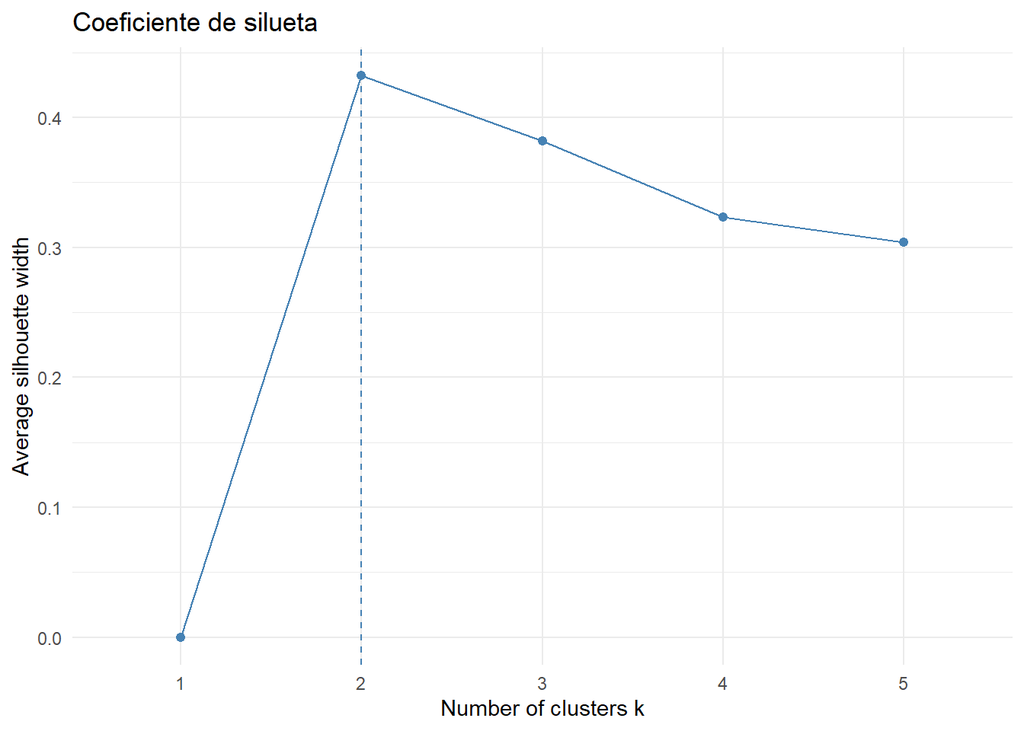

```r
set.seed(12345)
fviz_nbclust(pca_data, kmeans, method = "silhouette", k.max = 5) +
  theme_minimal() + ggtitle("Coeficiente de silueta")
```

Since the highest silhouette value is associated with two clusters, we can conclude that two out of the three methods identify two clusters as the optimal number.

### 7.2.2 Apply K-Means to the PCA-reduced dataset

In K-Means clustering, nstart determines the number of times the algorithm will be run with different random initial cluster centers. Each run produces a clustering result, and the algorithm selects the best one based on the lowest total within-cluster sum of squares (WCSS).

**Why use nstart = 25?** - K-Means is sensitive to the initial placement of centroids. Poor initialization can lead to suboptimal clusters.

- By setting nstart = 25, the algorithm runs 25 different initializations, reducing the risk of poor local minima.
- The best clustering solution is selected based on the lowest WCSS, ensuring better stability and accuracy.
- nstart = 25 is a common best practice, providing a good trade-off between computation time and clustering performance.

In summary: Using nstart = 25 improves K-Means results by increasing stability and avoiding bad initializations.

```r
# ---- Apply K-Means Clustering ----
k_opt <- 2  #  optimal number of clusters k

kmeans_result <- kmeans(pca_data, centers = k_opt, nstart = 25)
```

### 7.2.3 Visualize the clustered data

This scatter plot represents the results of K-Means clustering applied to PCA-reduced data, with the first two principal components (PC1 & PC2) as axes. The data points are color-coded according to their assigned cluster.

**Key Observations:**

- The two clusters (1 & 2) are well-separated, suggesting that K-Means effectively grouped similar observations.
- The division appears to be linear, which is characteristic of K-Means clustering when data is well-structured.
- There is some overlap at the center, indicating that some points may be close to the decision boundary between clusters.

**Interpretation:**

- The clustering structure suggests that two groups capture the main patterns in the data.
- If we suspect that more clusters might be needed, we could re-evaluate using methods like the Elbow Method or Silhouette Score.
- If the goal is business segmentation, each cluster could represent distinct customer groups with different characteristics.

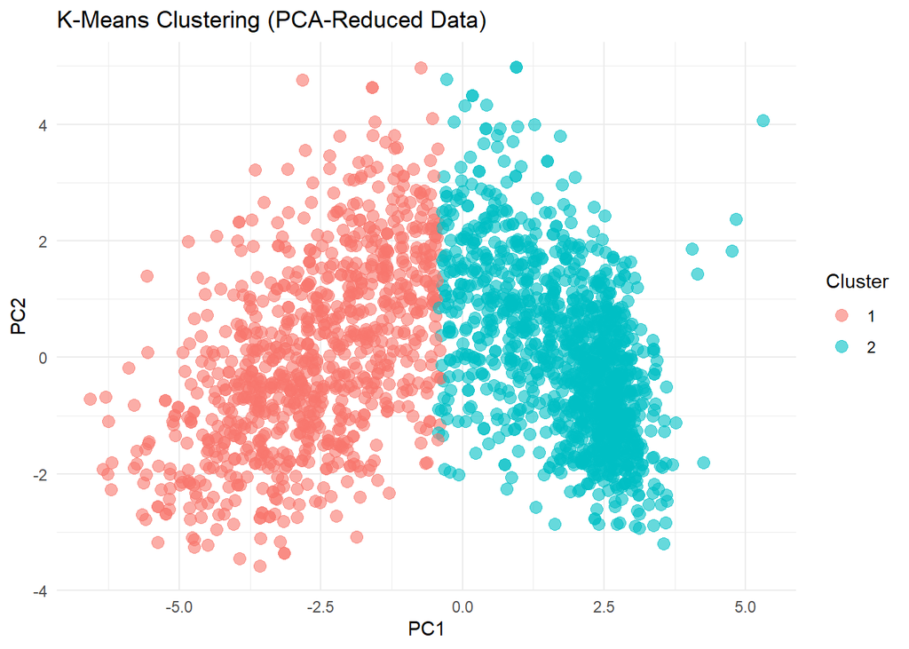

```r
# Add cluster labels to the dataset
pca_data$Cluster_KMeans <- as.factor(kmeans_result$cluster)

# ---- Visualize the Clusters ----
ggplot(pca_data, aes(x = PC1, y = PC2, color = Cluster_KMeans)) +
  geom_point(alpha = 0.6, size = 3) +
  theme_minimal() +
  labs(title = "K-Means Clustering (PCA-Reduced Data)", color = "Cluster")
```

For this dataset, **K-Means appears to be the better choice** because it provides a cleaner and more distinct separation between clusters. Agglomerative Clustering may be more useful if we expect hierarchical structures in the data, but for this particular case, K-Means’ crisp partitioning is preferable.

```r
library(plotly)

plot_ly(pca_data,
        x = ~PC1,
        y = ~PC2,
        z = ~PC3,
        color = ~Cluster_KMeans,
        type = "scatter3d",
        mode = "markers",
        marker = list(size = 4, opacity = 0.6))
```

[interactive chart not shown]

# 8 **Cluster Characterization and Insights**

Based on these results, we could segment customers into two groups. Next, we will analyze the patterns within the formed clusters and characterize the customers in each segment to gain deeper insights into their behaviors and attributes. Understanding these groupings will help refine marketing strategies and enhance customer engagement.

To achieve better clustering results, we could explore various modeling approaches. For instance, in agglomerative clustering, testing different linkage methods could help assess how segmentation varies. Similarly, adjusting the similarity measure in both approaches might impact the quality of the identified clusters. Additionally, automating the evaluation of different models using all three clustering methods can be highly beneficial for optimizing customer segmentation projects. We will cover these types of automation in future guides.

## 8.1 Add cluster labels to the original dataset

To properly characterize the clusters, we need to map the cluster assignments back to the original dataset. Since we performed PCA for dimensionality reduction before clustering, we must ensure that each individual retains its correct cluster label when merging the results.

Steps to Map Clusters Back to the Original Data:

1️⃣ Ensure Index Consistency: Since PCA transformation does not alter the order of observations, we can directly append the cluster labels to the original dataset.

2️⃣ Merge Cluster Labels: Add the cluster assignments from the PCA-reduced dataset to the original dataset using a column like Cluster_ID.

3️⃣ Check for Integrity: Verify that all individuals in the original dataset have been assigned a cluster and that no mismatches occurred.

```r
# Add cluster labels to the original dataset
data_fin_all$Cluster <- factor(kmeans_result$cluster)  # For K-Means

# Verify the distribution of clusters
table(data_fin_all$Cluster)
```

```
##
##    1    2
##  914 1298
```

This confirms that our clustering method has identified two distinct segments in the data. The next step is to analyze and compare these clusters based on key attributes to understand their differences.

- **Balanced Clusters:** The difference between 914 and 1,298 is not extreme, meaning the clustering process has not created an excessively unbalanced segmentation.
- **Potential Impact:** If one cluster were much smaller, we might worry about overfitting when using these clusters for predictive modeling.
- **Actionable Insight:** If the imbalance were larger, we could consider alternative distance metrics, linkage methods (for hierarchical clustering), or even re-evaluating the number of clusters.

Now, you are free to conduct any exploratory analysis to profile the customers. Here are some examples.

## 8.2 Cluster’s profile based on income and Recency

```r
library(ggplot2)
library(plotly)

p <- ggplot(data_fin_all, aes(x = Recency, y = Income, color = as.factor(Cluster),
                      text = paste("ID:", ID, "<br>Income:", Income, "<br>Recency:", Recency))) +
  geom_point(alpha = 0.7, size = 2) +
  scale_color_manual(values = c("#8DA0CB", "#800020")) +
  theme_minimal() +
  labs(title = "Cluster Profile: Income vs. Recency",
       x = "Recency (Days Since Last Purchase)",
       y = "Income",
       color = "Cluster") +
  theme(legend.position = "top")

plotly_plot <- ggplotly(p, tooltip = "text")

plotly_plot
```

[interactive chart not shown]

The chart illustrates the relationship between Recency (days since last purchase) and Income for each cluster. Some key observations:

**Cluster distribution:**

- Cluster 1 appears to include customers with higher average income.
- Cluster 2 is concentrated among lower-income customers.

**Relationship with Recency:**

- There is no clear distinction in Recency between clusters, as both groups cover a similar range on the X-axis.
- However, some higher-income customers in Cluster 1 have made recent purchases (low Recency).

Let’s review the distribution fpr each variable.

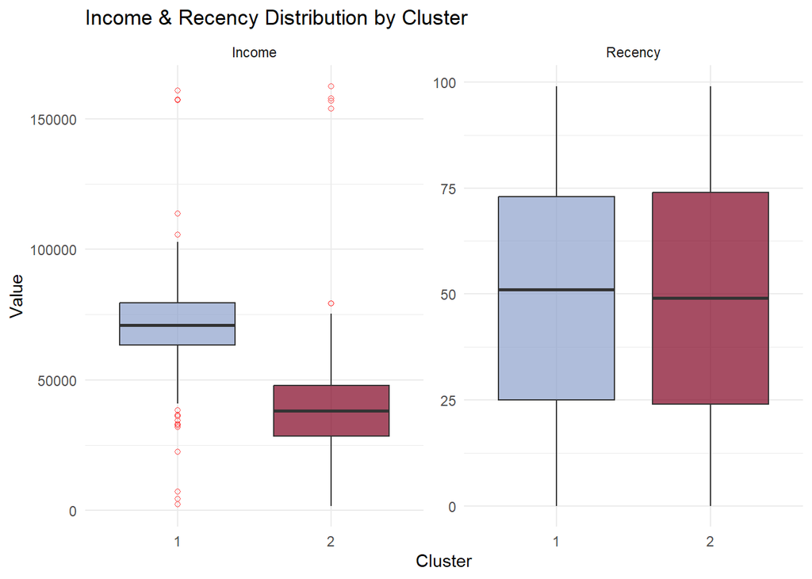

```r
library(ggplot2)

# Reshape data for faceting
data_long <- data_fin_all %>%
  select(Cluster, Income, Recency) %>%
  pivot_longer(cols = c(Income, Recency), names_to = "Variable", values_to = "Value")

# Boxplot with facet_wrap
p <- ggplot(data_long, aes(x = as.factor(Cluster), y = Value, fill = as.factor(Cluster))) +
  geom_boxplot(alpha = 0.7, outlier.color = "red", outlier.shape = 1) +
  facet_wrap(~Variable, scales = "free") +
  scale_fill_manual(values = c("#8DA0CB", "#800020")) +  # Burgundy & Dark Blue
  theme_minimal() +
  labs(title = "Income & Recency Distribution by Cluster",
       x = "Cluster",
       y = "Value",
       fill = "Cluster") +
  theme(legend.position = "none")

# Mostrar el gráfico
print(p)
```

**Recency Distribution:**

- Both clusters show similar medians and distributions for recency.
- Cluster 2 has slightly more recent purchases on average.

## 8.3 Cluster’s profile based on Age

```r
p <- ggplot(data_fin_all, aes(x = as.factor(Cluster), y = Age, fill = as.factor(Cluster))) +
  geom_boxplot(alpha = 0.7) +
  scale_fill_manual(values = c("#8DA0CB", "#800020")) +
  theme_minimal() +
  labs(title = "Age Distribution by Cluster",
       x = "Cluster",
       y = "Age",
       fill = "Cluster")

ggplotly(p)
```

[interactive chart not shown]

- Cluster 1 has a higher median age and a wider interquartile range.
- Cluster 2 has a lower median income, with more concentration around the lower range.

## 8.4 Cluster’s profile based on income and total spents

We can create a new variable to analyze each cluster and the total spending for each group. There is a positive relationship between income and total spent. As income increases, total spending also tends to rise.

**Cluster Differentiation:**

- Cluster 1 (light blue): Represents individuals with a wider distribution of income and spending, reaching higher spending values (above 2000).
- Cluster 2 (burgundy): Contains individuals with lower income and more limited total spending (mostly below 1000).

```r
# Total spendings on various items
data_fin_all$Spent <- data_fin_all$MntWines + data_fin_all$MntFruits + data_fin_all$MntMeatProducts +
                      data_fin_all$MntFishProducts + data_fin_all$MntSweetProducts + data_fin_all$MntGoldProds


p <- ggplot(data_fin_all, aes(x = Spent, y = Income, color = as.factor(Cluster),
                      text = paste("ID:", ID, "<br>Income:", Income, "<br>Spent:", Spent))) +
  geom_point(alpha = 0.7, size = 2) +
  scale_color_manual(values = c("#8DA0CB", "#800020")) +
  theme_minimal() +
  labs(title = "Cluster Profile: Income vs. Spent",
       x = "Total spent",
       y = "Income",
       color = "Cluster") +
  theme(legend.position = "top")

plotly_plot <- ggplotly(p, tooltip = "text")

plotly_plot
```

[interactive chart not shown]

```r
p <- ggplot(data_fin_all, aes(x = as.factor(Cluster), y = Spent, fill = as.factor(Cluster))) +
  geom_boxplot(alpha = 0.7) +
  scale_fill_manual(values = c("#8DA0CB", "#800020")) +
  theme_minimal() +
  labs(title = "Spent Distribution by Cluster",
       x = "Cluster",
       y = "Spent",
       fill = "Cluster")

ggplotly(p)
```

[interactive chart not shown]

The following bar chart shows the average spending distribution for each cluster, revealing how each group tends to allocate their spending across different categories.

- Both Cluster 1 and Cluster 2 spend the most on Wines and Meat, with Wines being the largest category in both cases.
- Cluster 1 (bottom bar): Spends proportionally more on Meat than Cluster 2.
- Cluster 2 (top bar): Allocates a noticeable portion to Gold, which is absent or minimal in Cluster 1. Has a similar spending pattern on Wines and Meat, but with a slightly larger share of Gold.

```r
# Load required libraries
library(dplyr)
library(tidyr)
library(ggplot2)
library(plotly)
library(scales)

# Calculate the share of each item in "Spent" per observation
data_fin_all <- data_fin_all %>%
  mutate(across(c(MntWines, MntFruits, MntMeatProducts,
                  MntFishProducts, MntSweetProducts, MntGoldProds),
                ~ . / Spent, .names = "Share_{.col}"))


# Compute the average share per cluster
cluster_avg <- data_fin_all %>%
  group_by(Cluster) %>%
  summarise(across(starts_with("Share_"), mean, na.rm = TRUE))

# Transform data to long format for visualization
cluster_avg_long <- cluster_avg %>%
  pivot_longer(cols = starts_with("Share_"),
               names_to = "Item",
               values_to = "Avg_Share") %>%
  mutate(Item = gsub("Share_", "", Item)) # Clean column names

cluster_avg_long <- cluster_avg_long %>%
  mutate(Item = recode(Item,
                       "MntWines" = "Wines",
                       "MntFruits" = "Fruits",
                       "MntMeatProducts" = "Meat",
                       "MntFishProducts" = "Fish",
                       "MntSweetProducts" = "Sweets",
                       "MntGoldProds" = "Gold"))

# Define custom colors (Make sure names match original column names before renaming)
custom_colors <- c(
  "Wines" = "#66C2A5",
  "Fruits" = "#800020",
  "Meat" = "#F79A77",
  "Fish" = "#d62728",
  "Sweets" = "#77F7A3",
  "Gold" = "#8DA0CB"
)


# Create the stacked bar chart (horizontal)
p <- ggplot(cluster_avg_long, aes(y = factor(Cluster), x = Avg_Share, fill = Item)) +
  geom_bar(stat = "identity", width = 0.6, aes(text = paste("Avg_Share:", percent(Avg_Share, accuracy = 1), "<br>Item:", Item))) +
  labs(title = "Average Spending Distribution per Cluster",
       y = "Cluster",
       x = "Spending Share",
       fill = "Item") +
  scale_x_continuous(labels = percent_format()) +  # Convert x-axis to percentage
  scale_fill_manual(values = custom_colors) +  # Custom colors and labels
  theme_minimal()

# Convert the plot to interactive with ggplotly
ggplotly(p, tooltip = "text")
```

[interactive chart not shown]

## 8.5 Count of promotion accepted

This bar chart illustrates the distribution of accepted promotions per cluster, showing how many promotions each group has accepted.

- The highest bars correspond to zero accepted promotions, indicating that most customers in both clusters did not engage with promotions.
- Cluster 2 (dark red) has a significantly larger portion of customers who did not accept any promotions compared to Cluster 1.
- Cluster 1 appears more responsive to promotions, with a slightly larger proportion of customers accepting at least one.
- Cluster 2 is less engaged overall, with most customers rejecting all promotions.

```r
data_fin_all$Total_Promos <- data_fin_all$AcceptedCmp1 + data_fin_all$AcceptedCmp2 +
                             data_fin_all$AcceptedCmp3 + data_fin_all$AcceptedCmp4 +
                             data_fin_all$AcceptedCmp5


custom_colors <- c("#8DA0CB", "#800020")

p <- ggplot(data_fin_all, aes(x = factor(Total_Promos), fill = factor(Cluster))) +
  geom_bar(aes(text = paste("Count:", after_stat(count))), position = "dodge") +
  labs(title = "Count Of Promotion Accepted",
       x = "Number of Total Accepted Promotions",
       y = "Count",
       fill = "Cluster") +
  theme_minimal() +
 scale_fill_manual(values = custom_colors)

ggplotly(p, tooltip = "text")
```

[interactive chart not shown]

## 8.6 Days as a costumer

The median number of days as a customer is comparable between the two clusters. This suggests that customer tenure is not a distinguishing factor between groups.

```r
p <- ggplot(data_fin_all, aes(x = as.factor(Cluster), y = Customer_For, fill = as.factor(Cluster))) +
  geom_boxplot(alpha = 0.7) +
  scale_fill_manual(values = c("#8DA0CB", "#800020")) +
  theme_minimal() +
  labs(title = "Days as a costumer distribution by Cluster",
       x = "Cluster",
       y = "Days as a costumer",
       fill = "Cluster")

ggplotly(p)
```

[interactive chart not shown]

## 8.7 Children at home

These two bar charts provide insights into the presence of young children and teenagers in households across clusters.

**Young Children (First Chart):**

- Cluster 1 (light blue) has a higher proportion of households with no young children.
- Cluster 2 (dark red) has more households with one young child.
- Households with two young children are rare in both clusters, with a slightly higher count in Cluster 2.

**Teenagers (Second Chart):**

- Cluster 2 has more households with no teenagers compared to Cluster 1.
- Both clusters have a significant number of households with one teenager, but Cluster 2 has a slightly higher count.
- Households with two teenagers are uncommon in both clusters.

```r
custom_colors <- c("#8DA0CB", "#800020")

p <- ggplot(data_fin_all, aes(x = factor(Kidhome), fill = factor(Cluster))) +
  geom_bar(aes(text = paste("Count:", after_stat(count))), position = "dodge") +
  labs(title = "Count of young children in the household",
       x = "Number of young children",
       y = "Count",
       fill = "Cluster") +
  theme_minimal() +
 scale_fill_manual(values = custom_colors)

ggplotly(p, tooltip = "text")
```

[interactive chart not shown]

```r
custom_colors <- c("#8DA0CB", "#800020")

p <- ggplot(data_fin_all, aes(x = factor(Teenhome), fill = factor(Cluster))) +
  geom_bar(aes(text = paste("Count:", after_stat(count))), position = "dodge") +
  labs(title = "Count of teenagers  in the household",
       x = "Number of teenagers ",
       y = "Count",
       fill = "Cluster") +
  theme_minimal() +
 scale_fill_manual(values = custom_colors)

ggplotly(p, tooltip = "text")
```

[interactive chart not shown]

## 8.8 Level of education

This graph shows the distribution of education levels for customers in each cluster. The clusters appear quite similar in education distribution, with only small variations. The differences are not drastic enough to suggest a strong segmentation based on education alone. If education were a major factor, we would expect to see one cluster dominating certain levels.

```r
custom_colors <- c("#8DA0CB", "#800020")

p <- ggplot(data_fin_all, aes(x = factor(Education), fill = factor(Cluster))) +
  geom_bar(aes(text = paste("Count:", after_stat(count))), position = "dodge") +
  labs(title = "Count costumers by level of education",
       x = "Level of education",
       y = "Count",
       fill = "Cluster") +
  theme_minimal() +
 scale_fill_manual(values = custom_colors)

ggplotly(p, tooltip = "text")
```

[interactive chart not shown]

## 8.9 Marital status

This chart shows the distribution of marital status across the two clusters. Cluster 2 seems to have more married customers, while Cluster 1 has a more balanced distribution.The difference in “Single” and “Together” categories suggests a potential segmentation based on lifestyle.

```r
custom_colors <- c("#8DA0CB", "#800020")

p <- ggplot(data_fin_all, aes(x = factor(Marital_Status), fill = factor(Cluster))) +
  geom_bar(aes(text = paste("Count:", after_stat(count))), position = "dodge") +
  labs(title = "Count costumers by marital status",
       x = "Marital status",
       y = "Count",
       fill = "Cluster") +
  theme_minimal() +
 scale_fill_manual(values = custom_colors)

ggplotly(p, tooltip = "text")
```

[interactive chart not shown]

## 8.10 General Conclusions for Each Cluster

The segmentation results provide valuable insights into customer behavior and purchasing patterns. However, it is important to note that in real-world applications, a more rigorous selection of clusters and features would be necessary to ensure higher accuracy. As previously mentioned, a deeper exploratory analysis should be conducted to validate whether the chosen number of clusters is optimal and if additional variables could enhance the segmentation. The current findings serve as an initial interpretation, but further refinements could improve the clarity and business relevance of the profiles.

### 8.10.1 Cluster 1: High-Value Consumers with Greater Purchasing Power

**Interpretation:** Cluster 1 represents a more financially stable segment that can afford to spend more freely, with a focus on premium products and food-related purchases.

### 8.10.2 Cluster 2: Price-Sensitive Families with Selective Luxury Spending

**Interpretation:** Cluster 2 consists of younger, family-oriented consumers who may have lower overall purchasing power but still allocate spending toward selective luxury items like gold. Their financial behavior could be shaped by budget-conscious decisions while still prioritizing family needs and specific indulgences.

## 8.11 Further Improvements for Better Segmentation and Profiling

While the current segmentation provides useful insights, there are several ways to enhance the accuracy and depth of customer profiling:

**Testing Different Clustering Methods:**

- Explore alternative algorithms like DBSCAN or hierarchical clustering to validate whether K-means was the best approach.
- Conduct silhouette analysis or the elbow method to confirm that two clusters are indeed the optimal choice.

**Adding More Features:**

- Incorporate demographic factors (e.g., income level, household size) for a more refined classification.
- Analyze behavioral data, such as frequency of purchases, response to promotions, or seasonal spending habits.

**Validating Cluster Stability:**

- Perform cross-validation techniques to check if the clusters remain stable when applied to different datasets.
- Compare results with real-world business knowledge to ensure that they align with customer realities.

**Exploring Sub-Segments Within Each Cluster:**

- Instead of using just two broad clusters, creating additional sub-groups may reveal hidden patterns within customer behavior.
- Segmenting by purchase category preferences (e.g., luxury-focused vs. essentials-driven) could improve targeting strategies.

**Conducting a Post-Clustering Analysis:**

- Investigate whether the segmentation correlates with profitability, customer lifetime value, or loyalty metrics.
- Use predictive modeling to test how cluster membership affects future spending behavior.